# Sex Differences

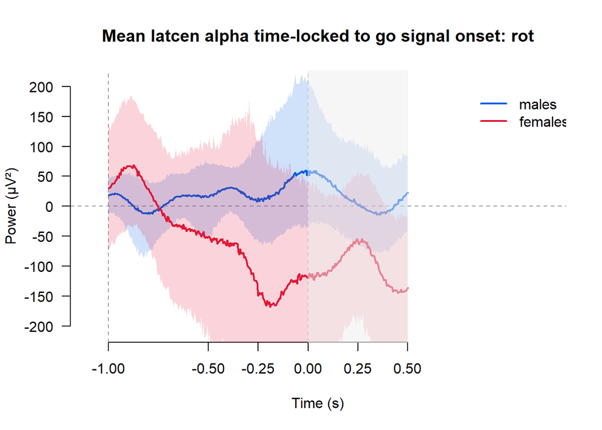

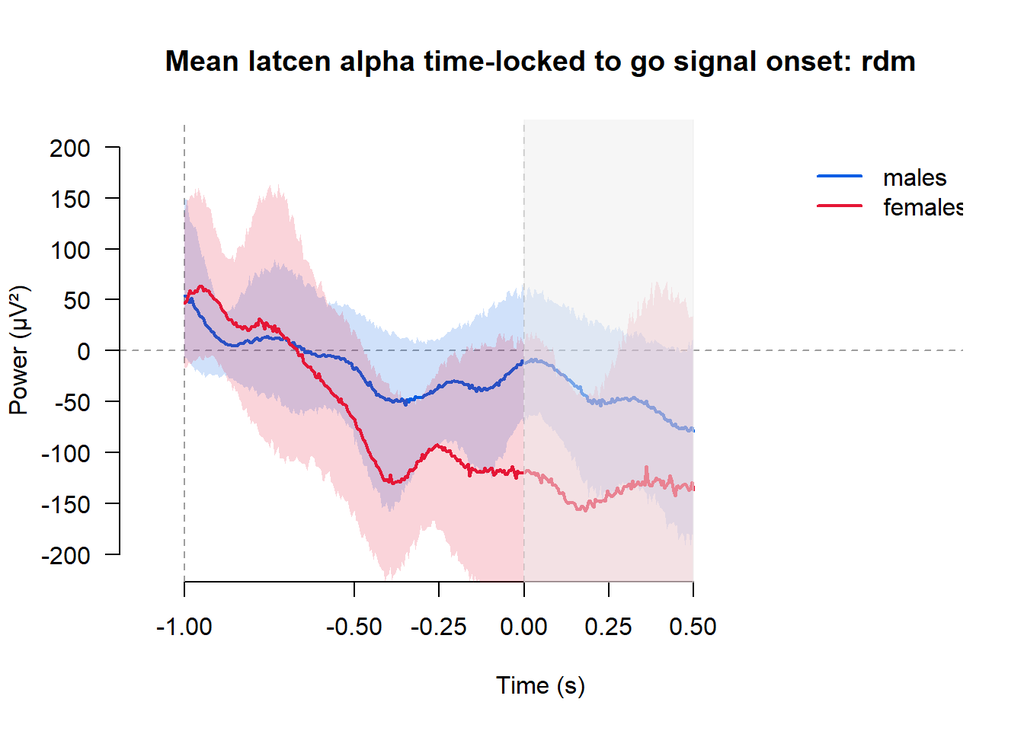

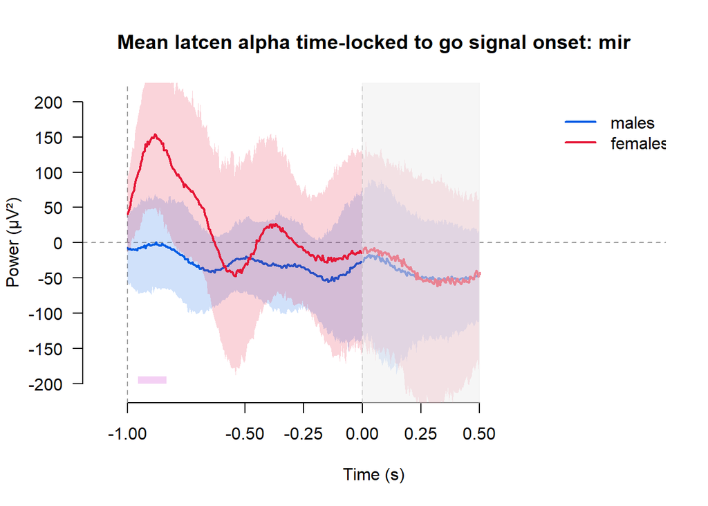

```r
plotSexPTypeTFRRPPermTestEarlyLateDiffWaves(freqs = 'alpha', roi = 'latcen')
```

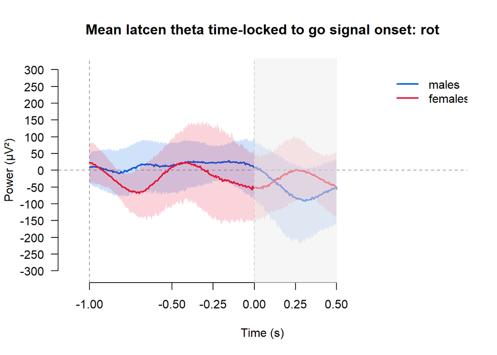

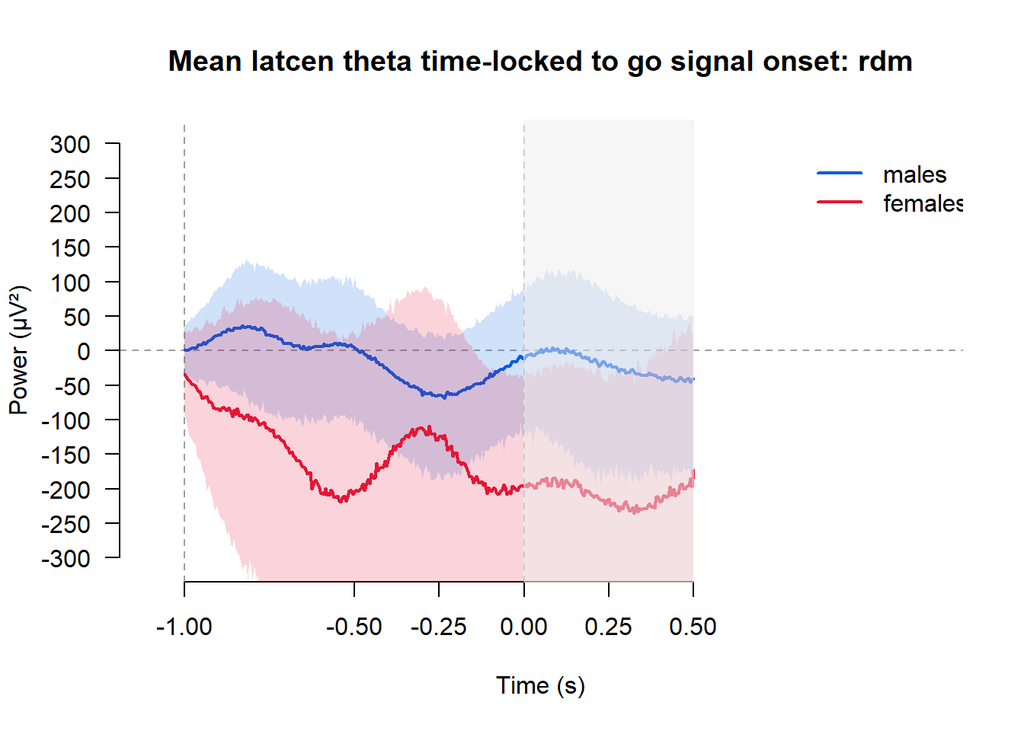

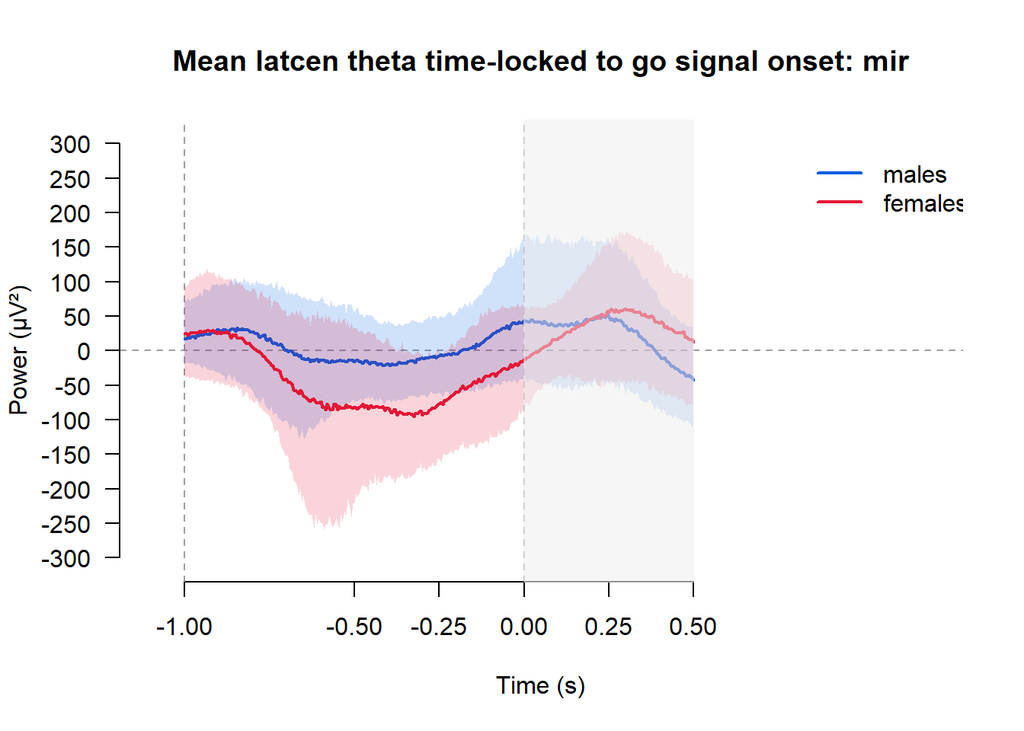

```r
plotSexPTypeTFRRPPermTestEarlyLateDiffWaves(freqs = 'theta', roi = 'latcen')
```

No significant clusters identified.

#### Small-large difference

##### medial frontal region

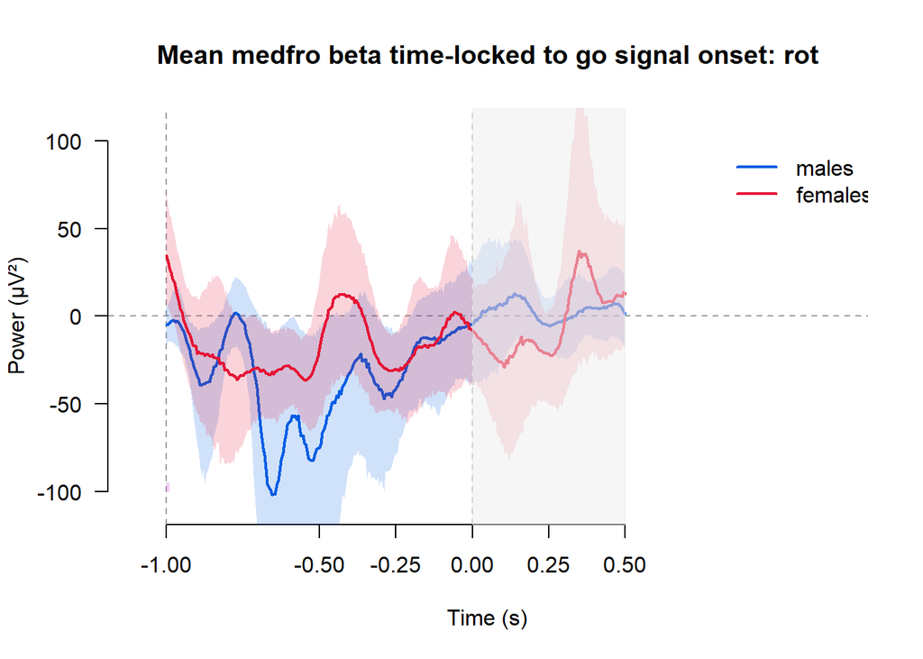

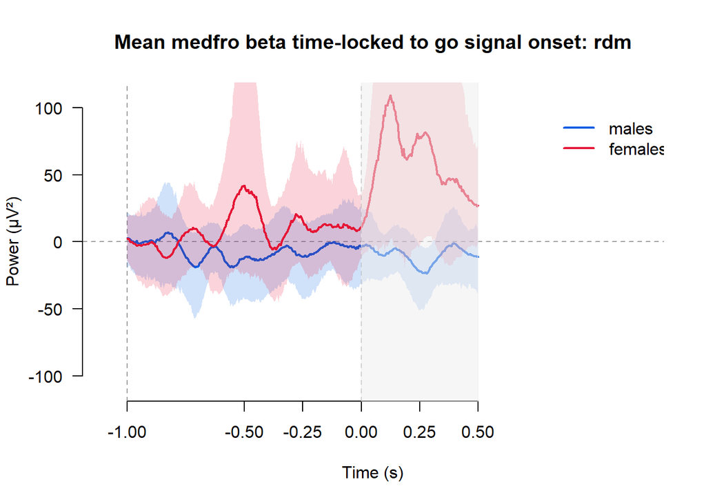

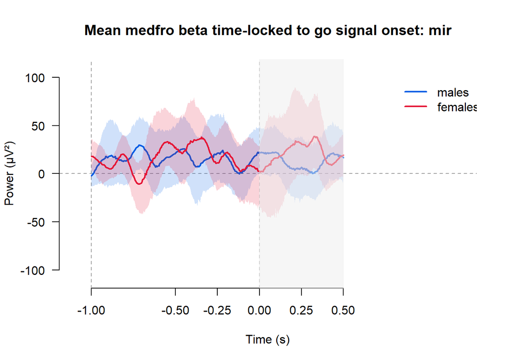

```r
plotSexPTypeTFRRPPermTestSmallLargeDiffWaves(freqs = 'beta', roi = 'medfro')
```

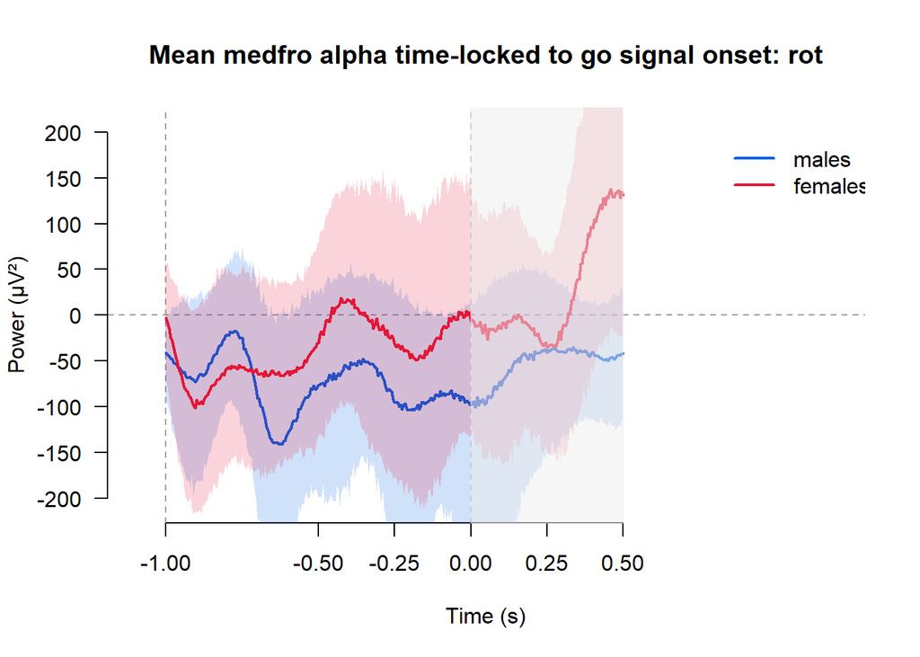

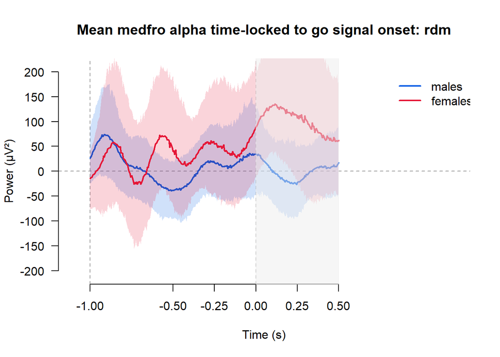

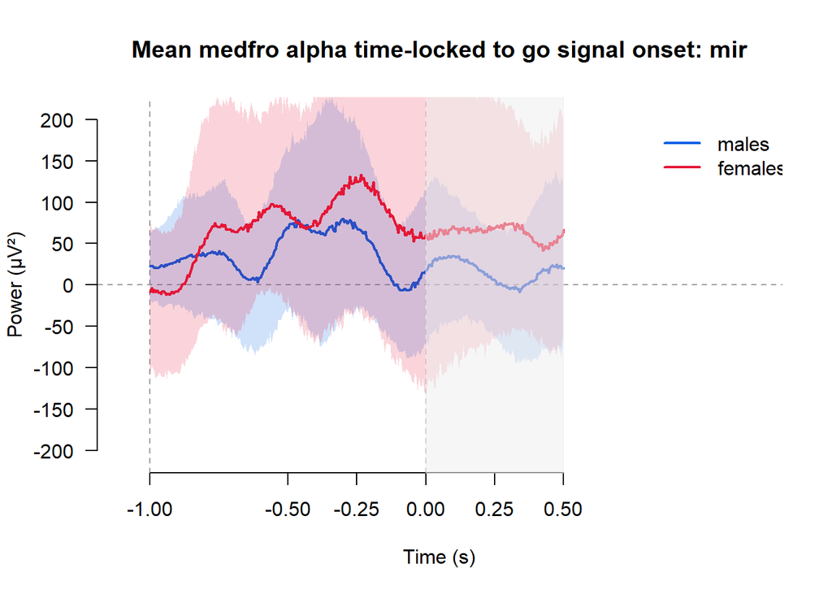

```r
plotSexPTypeTFRRPPermTestSmallLargeDiffWaves(freqs = 'alpha', roi = 'medfro')
```

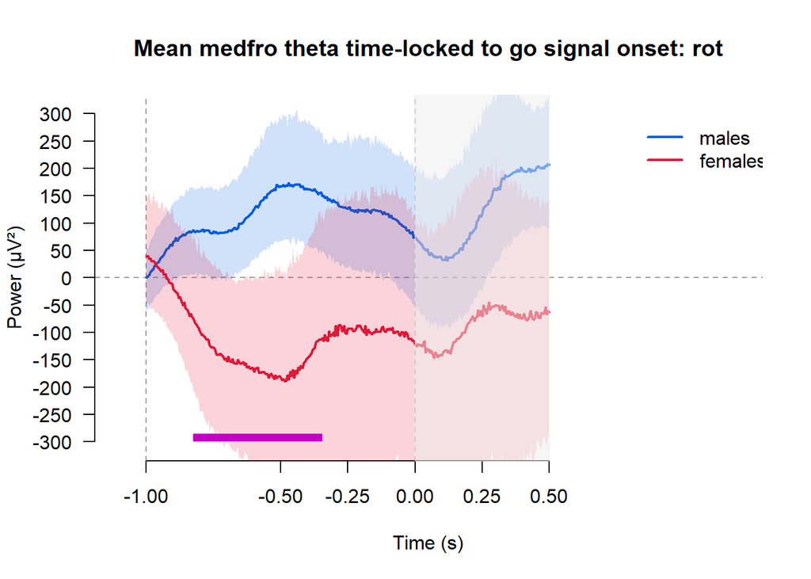

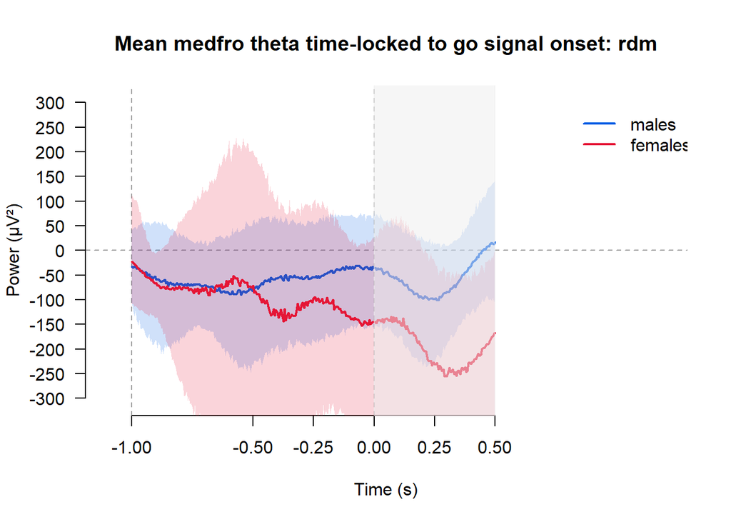

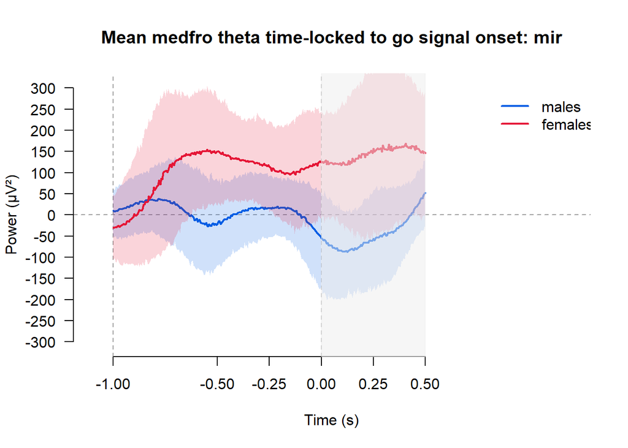

```r
plotSexPTypeTFRRPPermTestSmallLargeDiffWaves(freqs = 'theta', roi = 'medfro')
```

We find a difference between males and females during fixed rotation training in the medial frontal regions for the theta frequency band (-0.83 to -0.35 sec). This suggests that females had more negative-going theta activity for large errors than small errors, while the opposite pattern is observed in males. This may suggest different patterns of neural activity during movement preparation between the sexes.

##### lateral central region

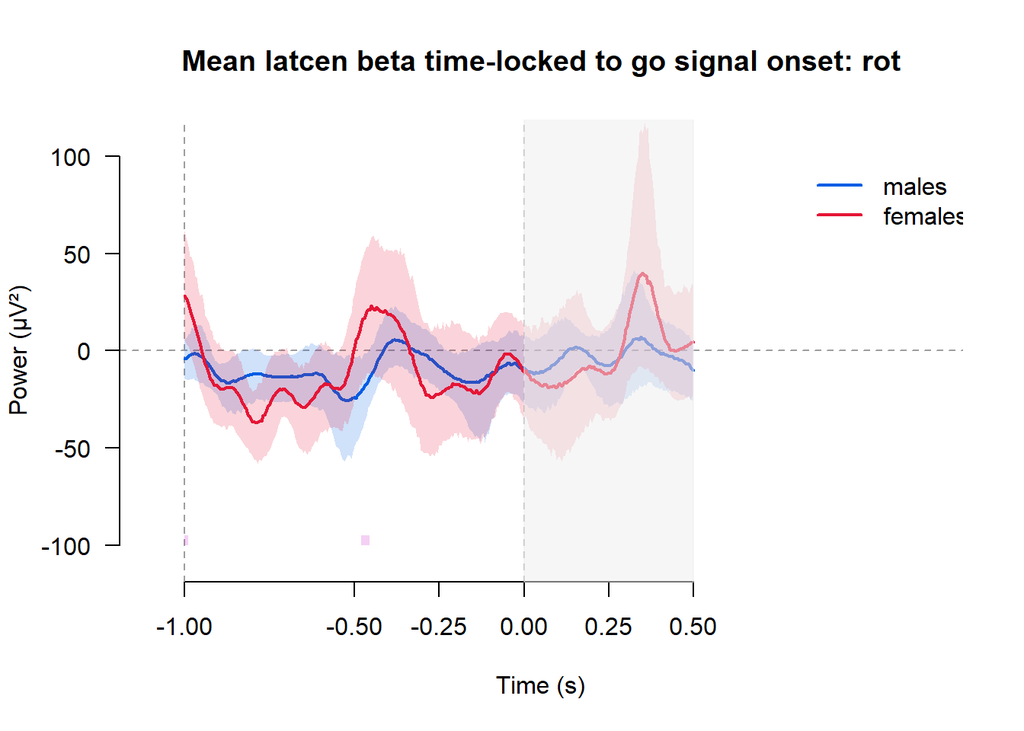

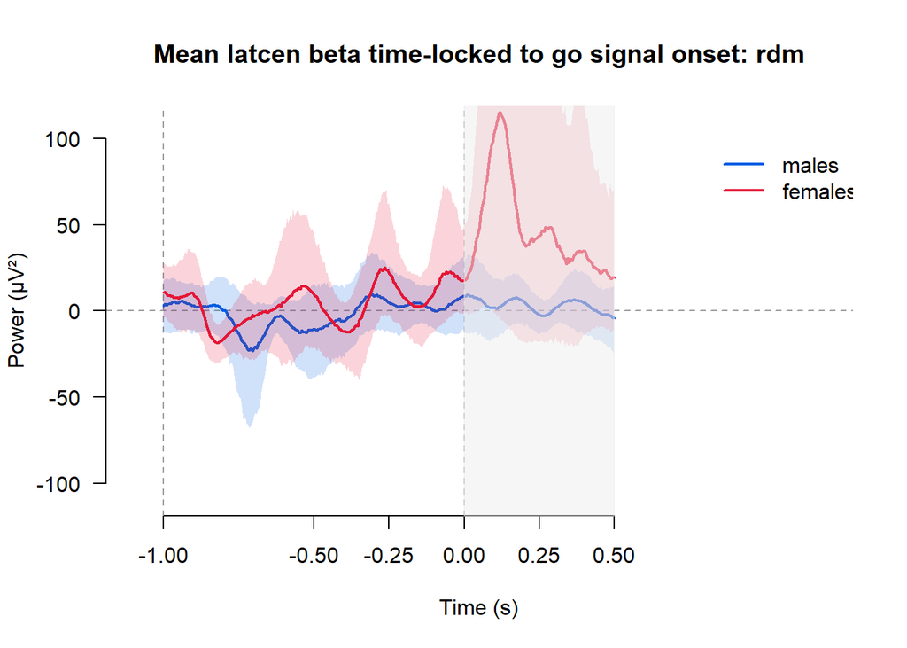

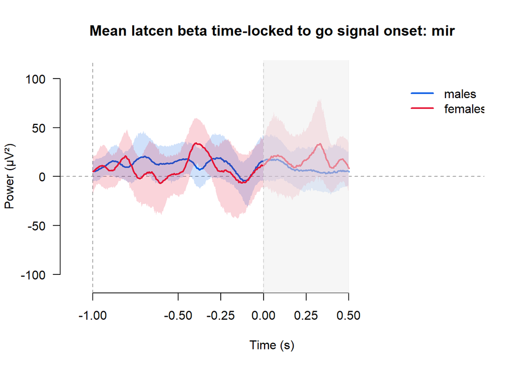

```r
plotSexPTypeTFRRPPermTestSmallLargeDiffWaves(freqs = 'beta', roi = 'latcen')
```

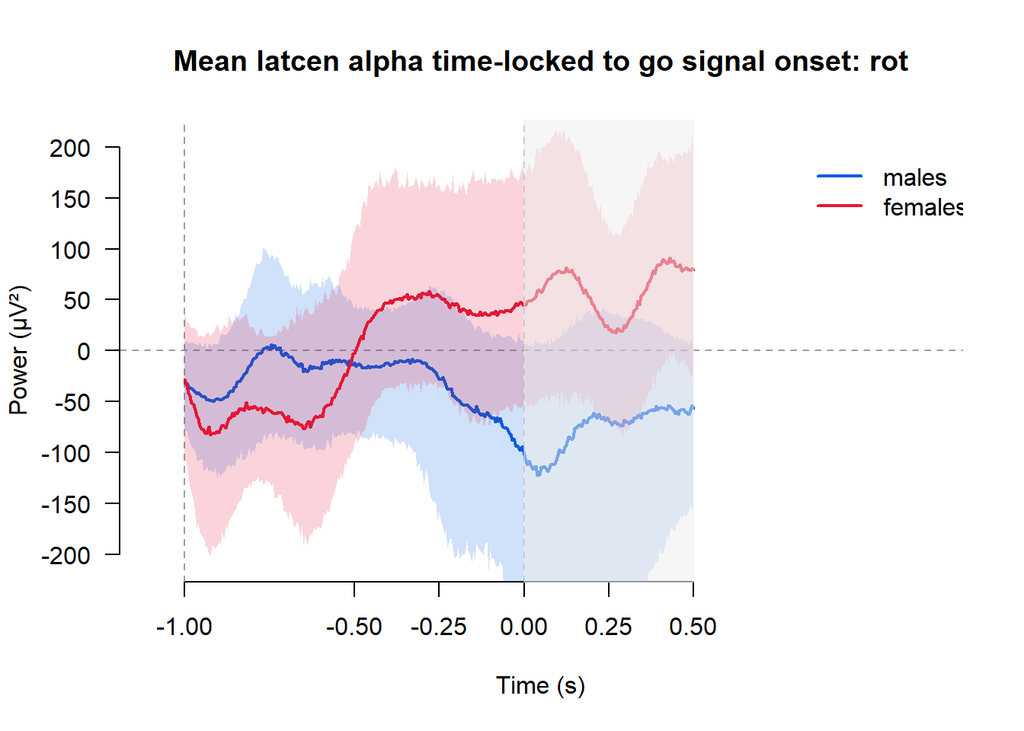

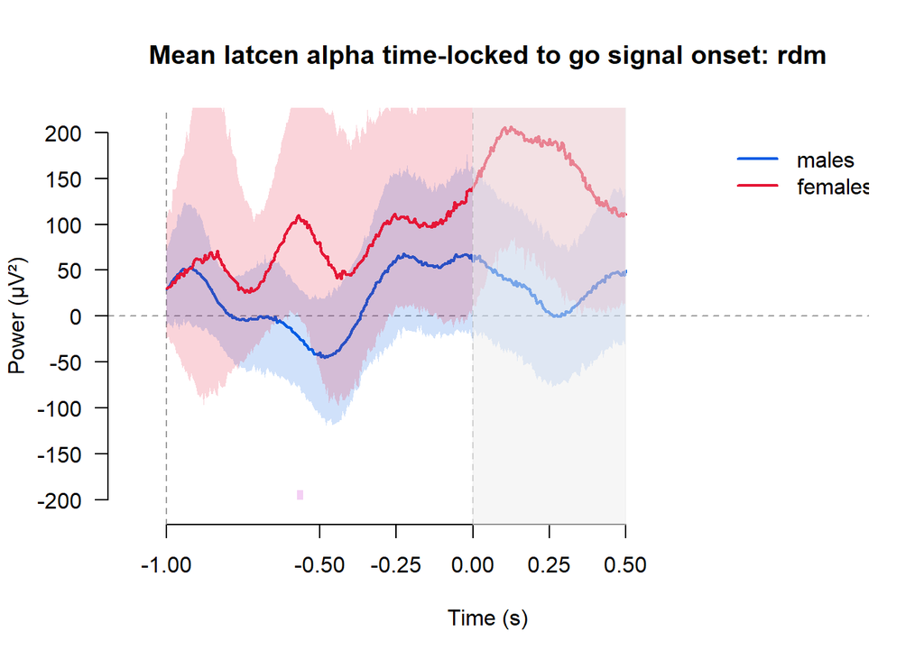

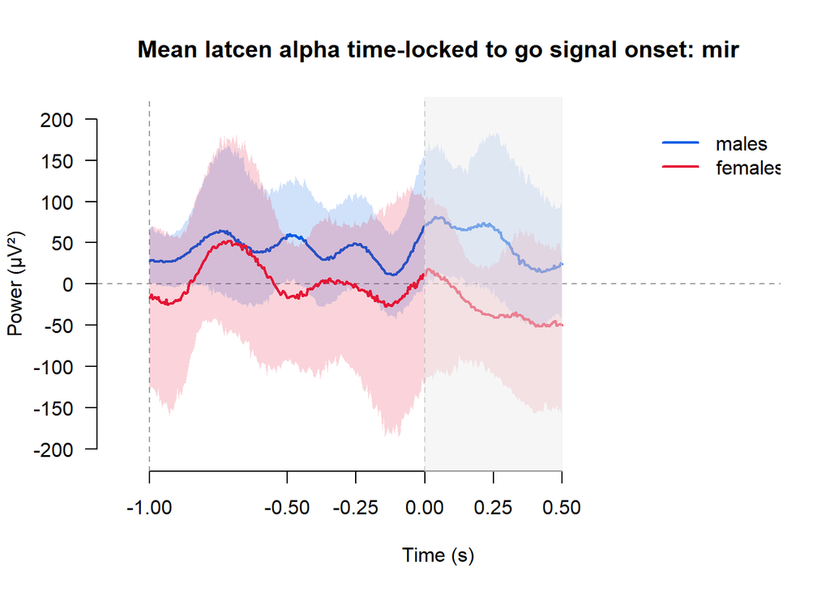

```r
plotSexPTypeTFRRPPermTestSmallLargeDiffWaves(freqs = 'alpha', roi = 'latcen')
```

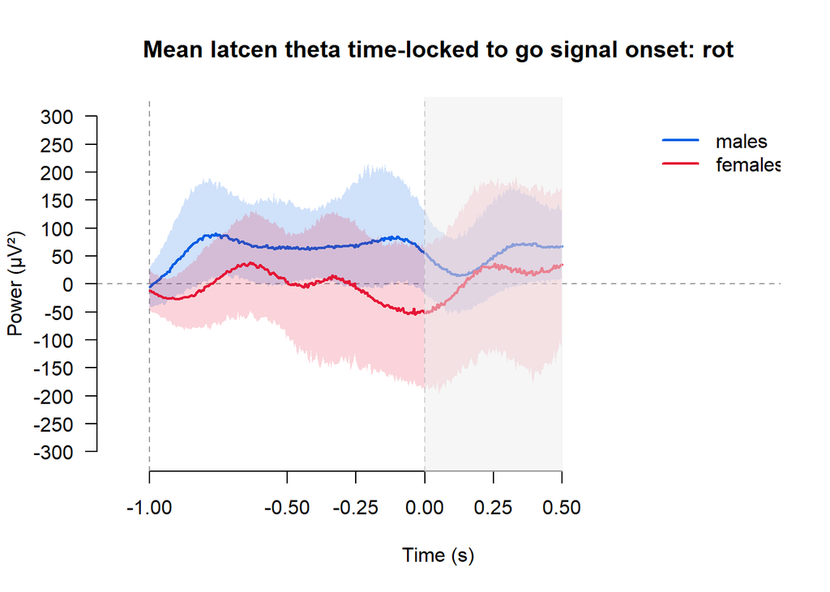

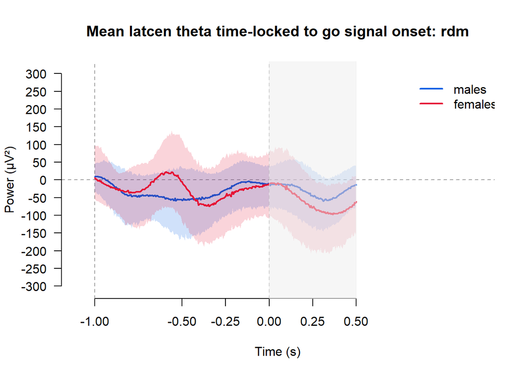

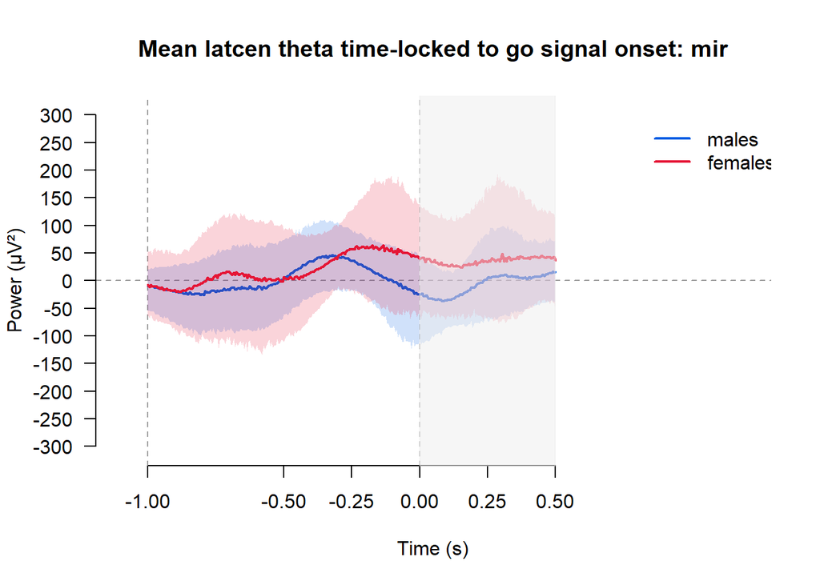

```r
plotSexPTypeTFRRPPermTestSmallLargeDiffWaves(freqs = 'theta', roi = 'latcen')
```

No significant clusters identified.

### Feedback processing

#### Early-late difference

##### medial frontal region

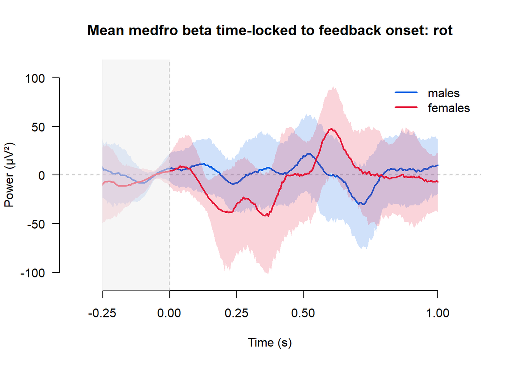

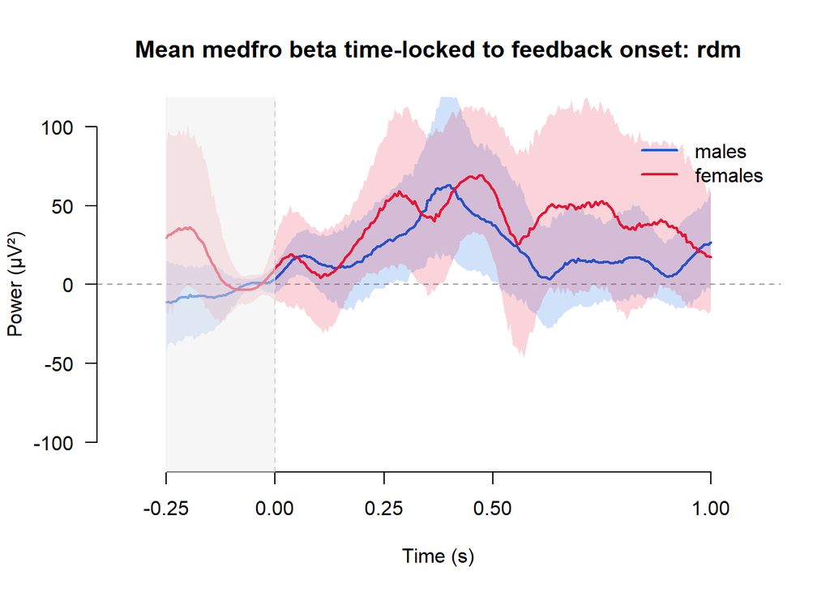

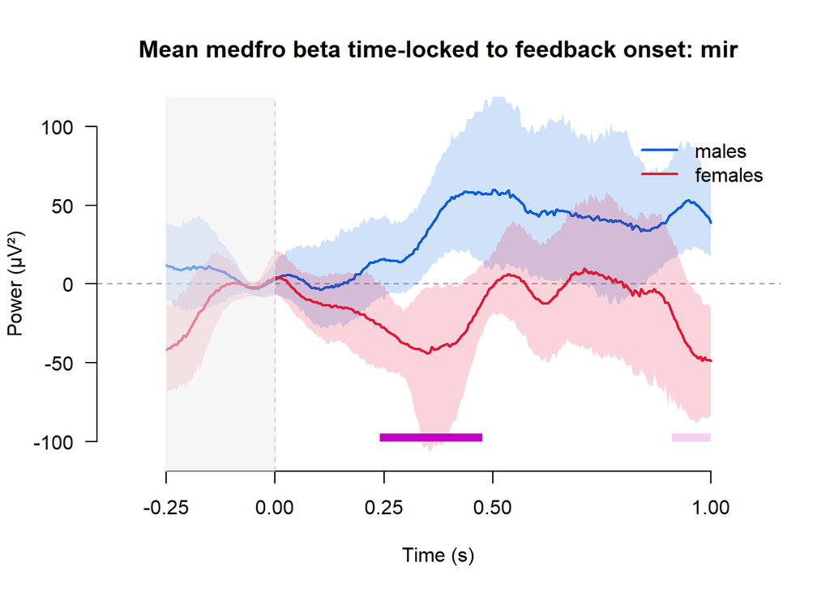

```r
plotSexPTypeTFRFRNPermTestEarlyLateDiffWaves(freqs = 'beta', roi = 'medfro')
```

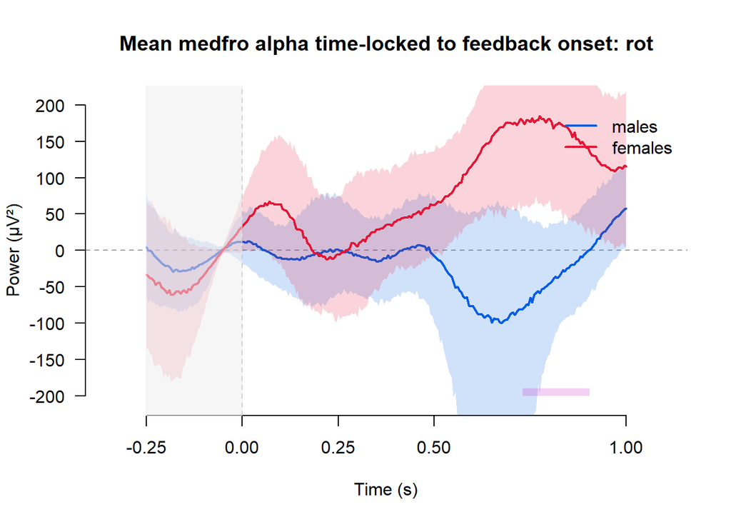

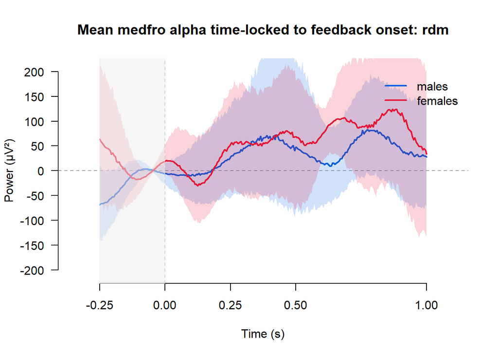

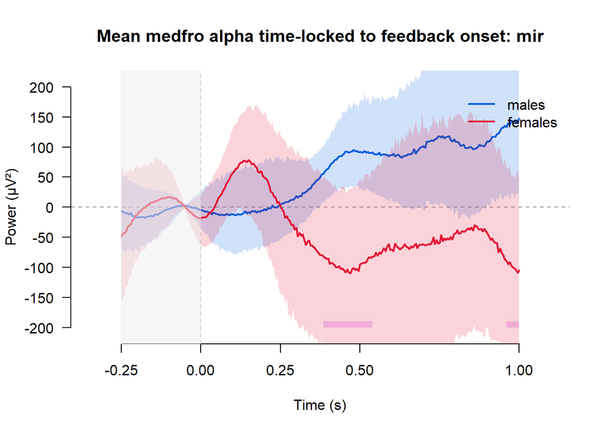

```r
plotSexPTypeTFRFRNPermTestEarlyLateDiffWaves(freqs = 'alpha', roi = 'medfro')
```

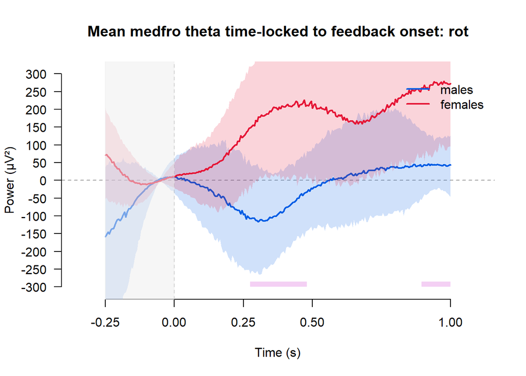

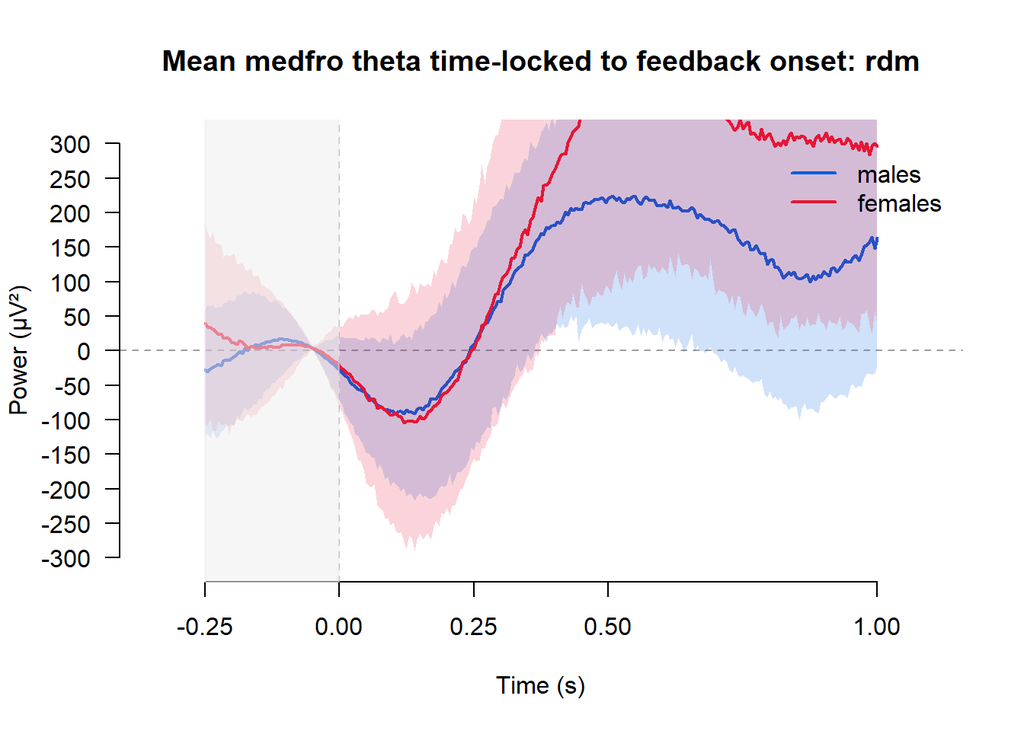

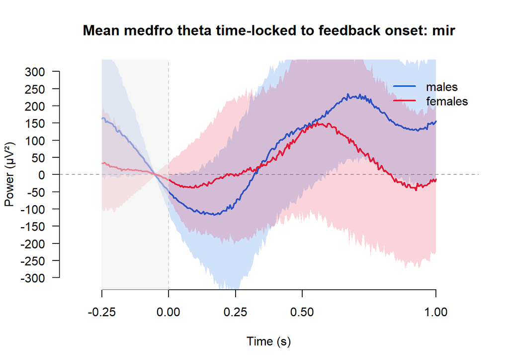

```r
plotSexPTypeTFRFRNPermTestEarlyLateDiffWaves(freqs = 'theta', roi = 'medfro')
```

We find a difference between males and females during mirror reversal training in the medial frontal regions for the beta frequency band (0.24 to 0.48 sec). This suggests that females had more negative-going beta activity during early compared to late training, while the opposite pattern is observed in males. This may suggest different patterns of neural activity during feedback processing between the sexes.

##### lateral central region

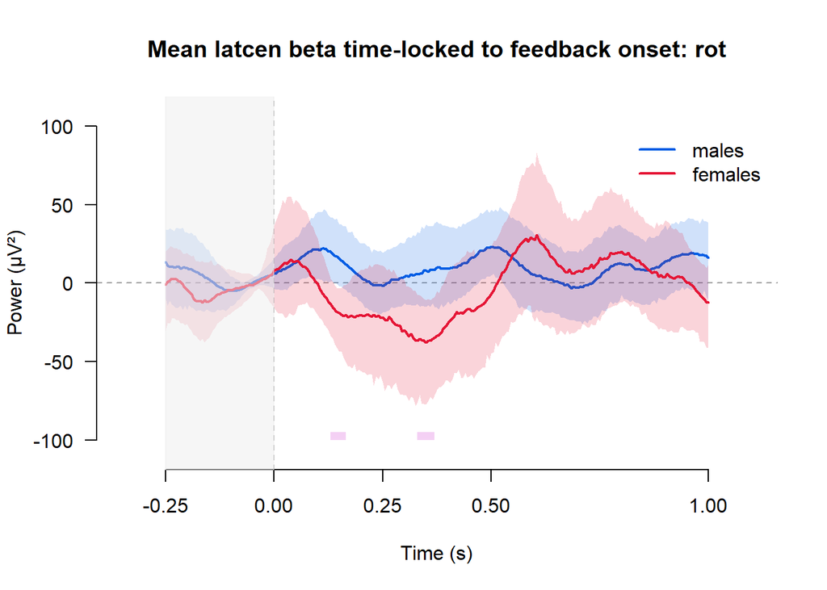

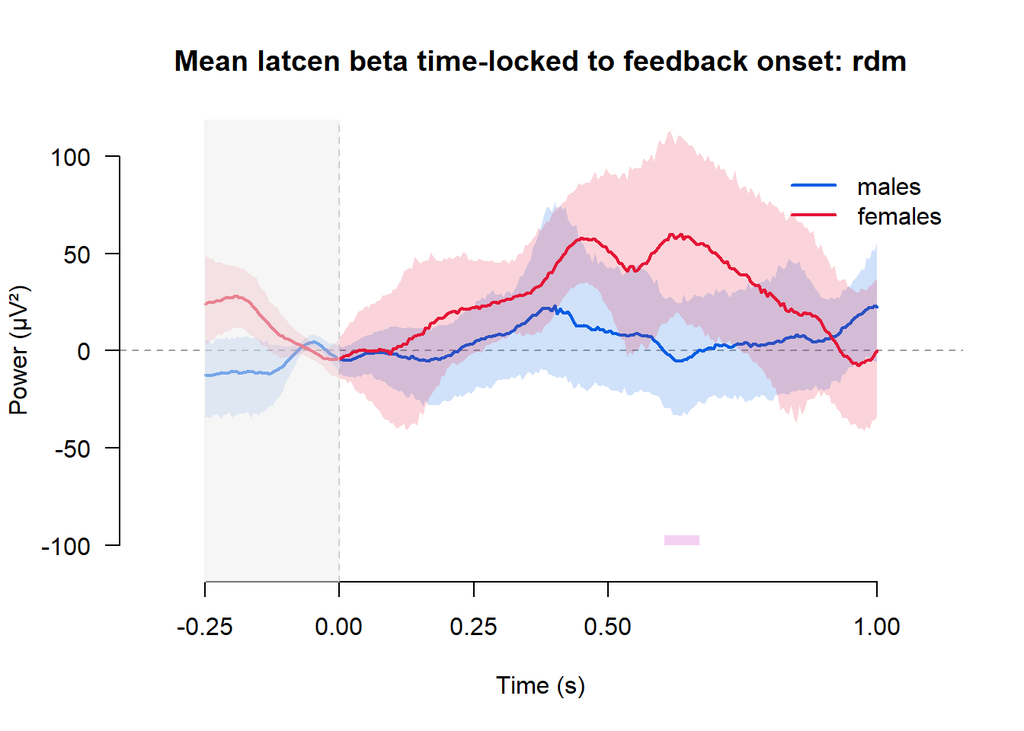

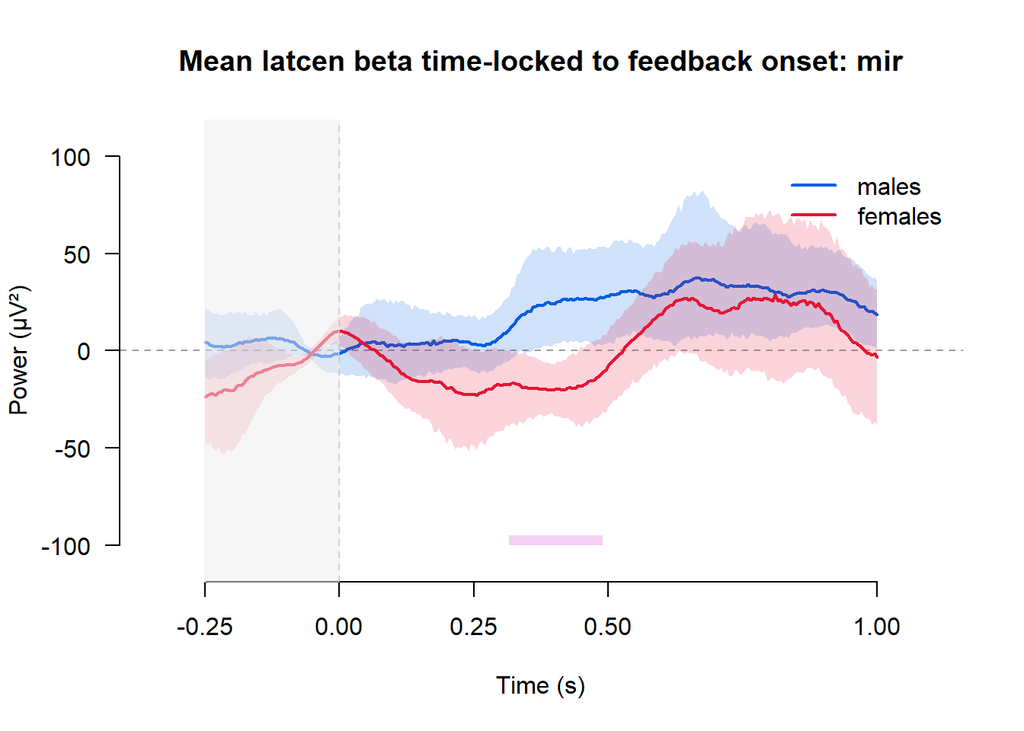

```r
plotSexPTypeTFRFRNPermTestEarlyLateDiffWaves(freqs = 'beta', roi = 'latcen')
```

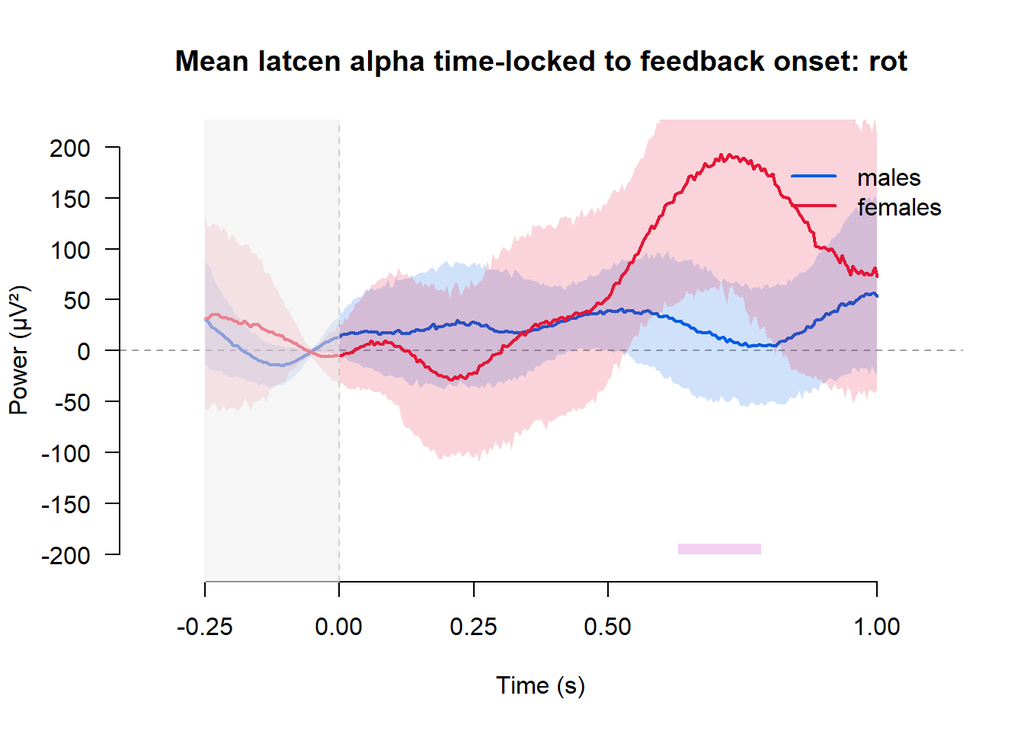

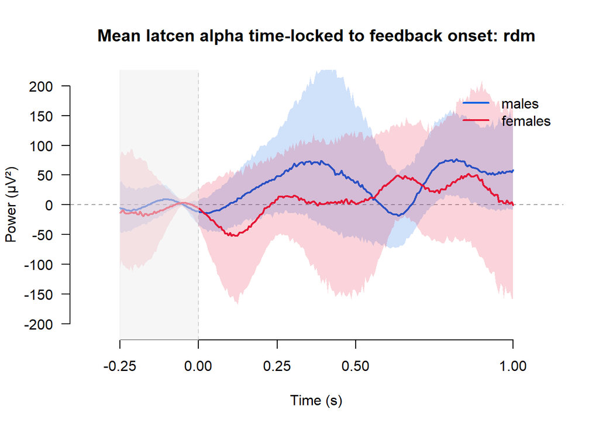

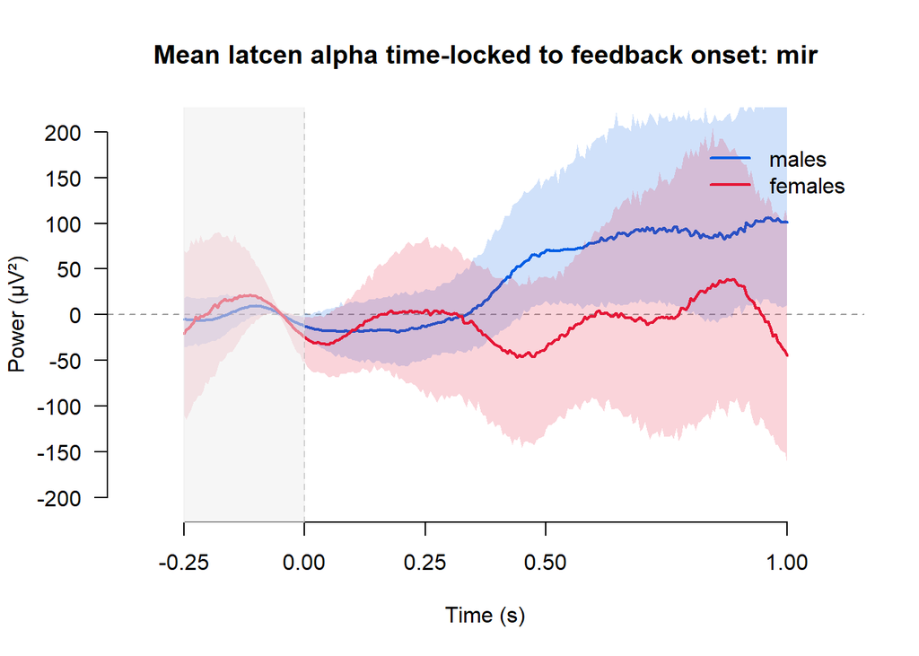

```r
plotSexPTypeTFRFRNPermTestEarlyLateDiffWaves(freqs = 'alpha', roi = 'latcen')
```

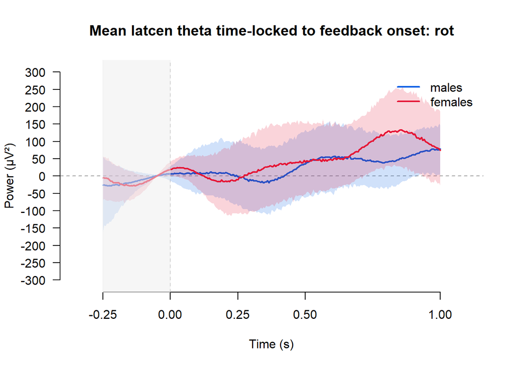

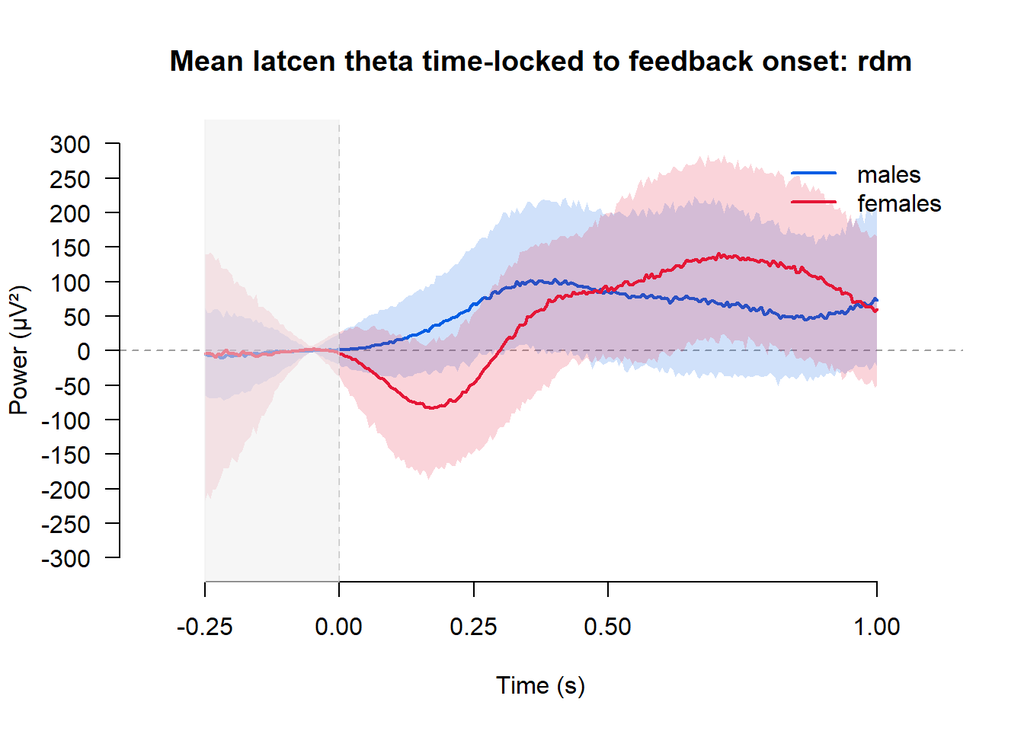

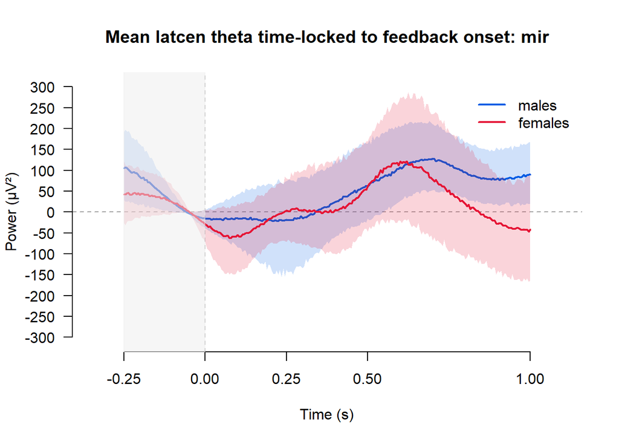

```r
plotSexPTypeTFRFRNPermTestEarlyLateDiffWaves(freqs = 'theta', roi = 'latcen')
```

No significant clusters identified.

#### Small-large difference

##### medial frontal region

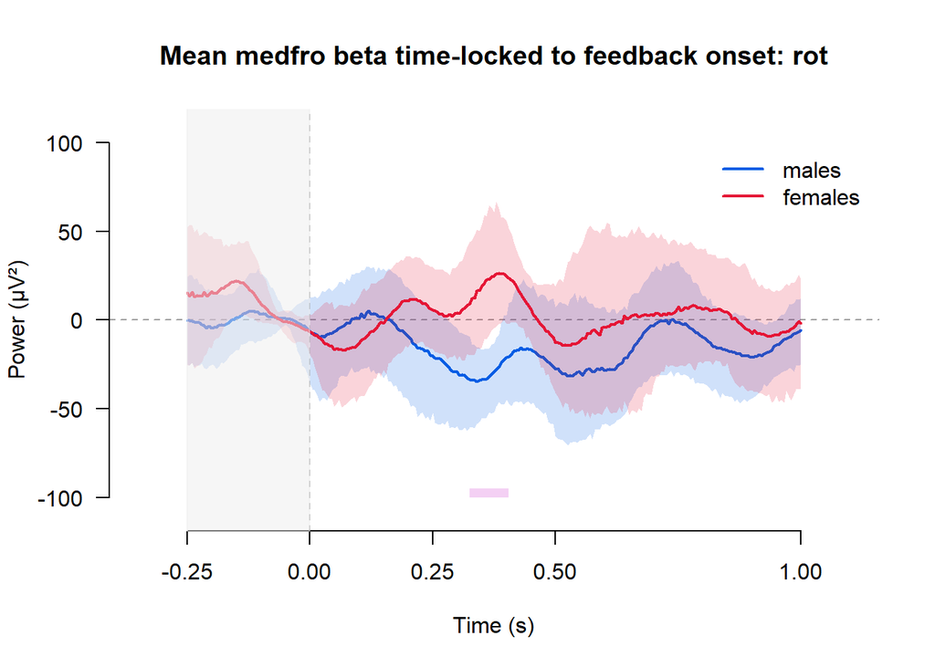

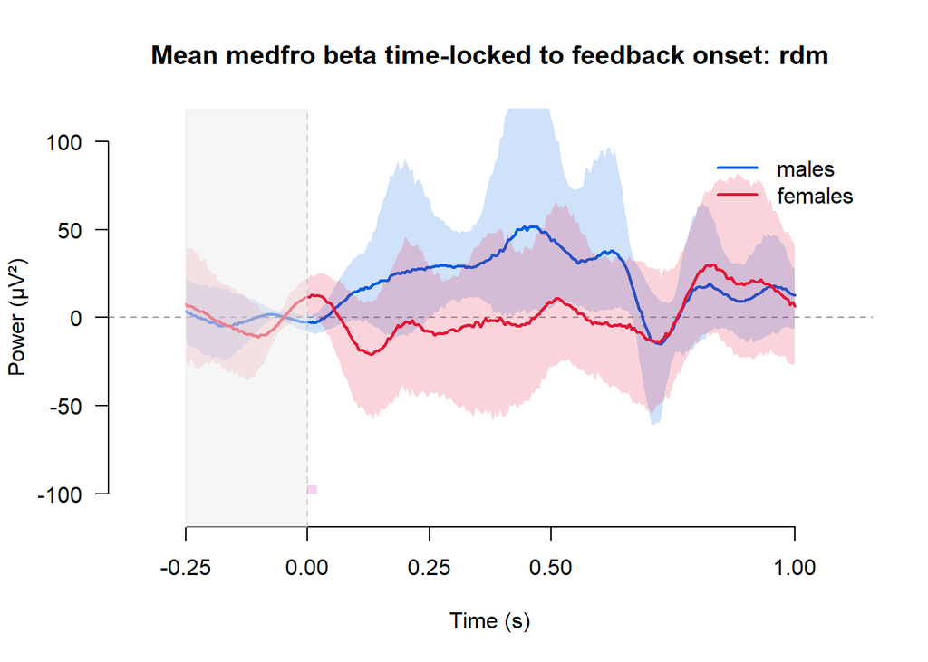

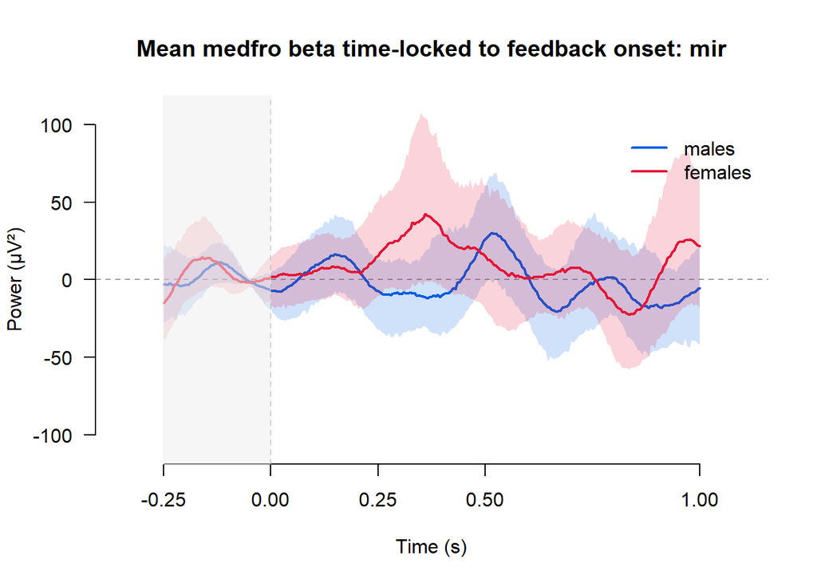

```r
plotSexPTypeTFRFRNPermTestSmallLargeDiffWaves(freqs = 'beta', roi = 'medfro')
```

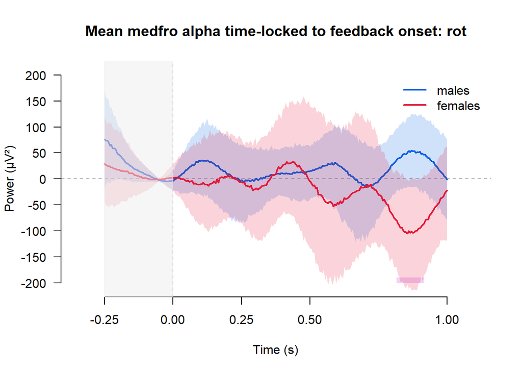

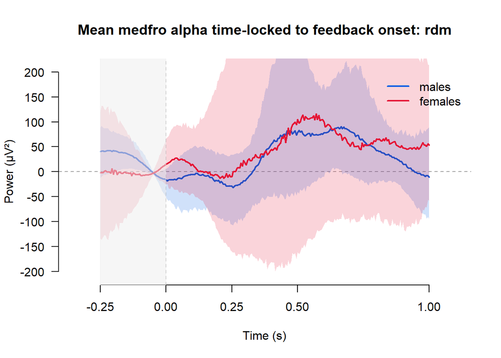

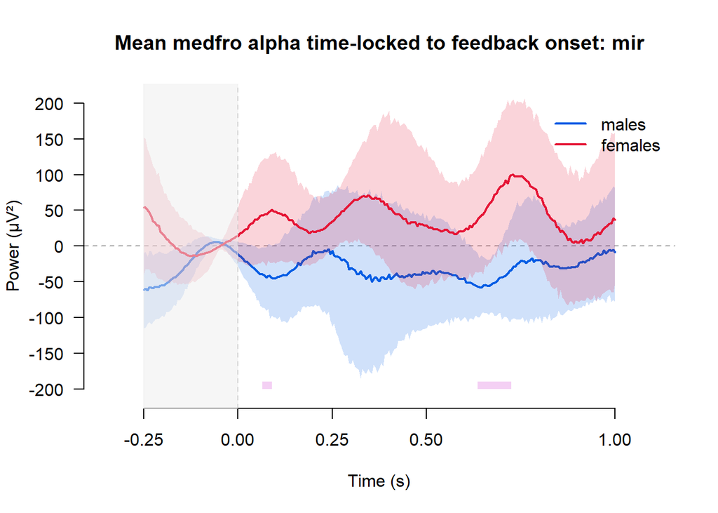

```r
plotSexPTypeTFRFRNPermTestSmallLargeDiffWaves(freqs = 'alpha', roi = 'medfro')
```

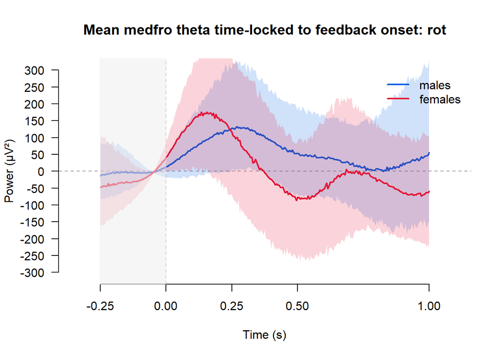

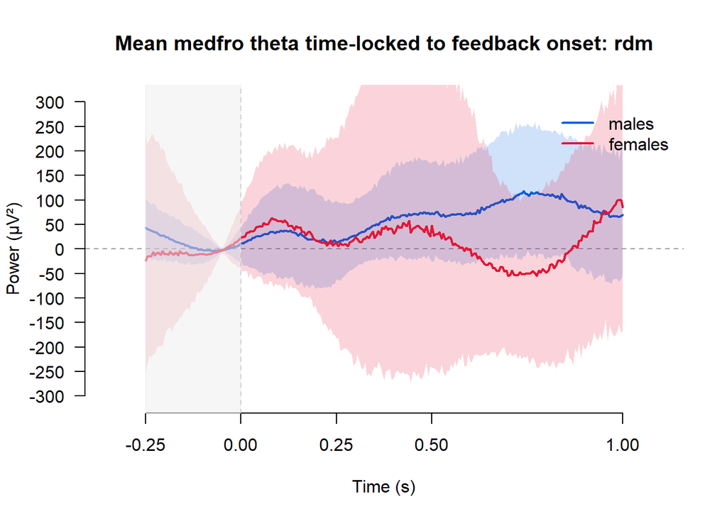

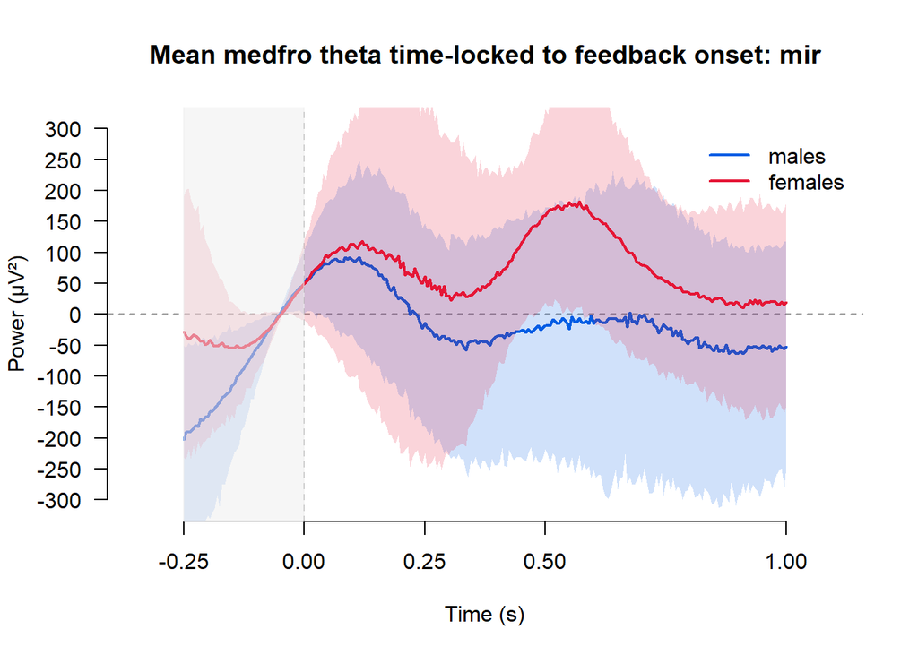

```r
plotSexPTypeTFRFRNPermTestSmallLargeDiffWaves(freqs = 'theta', roi = 'medfro')
```

No significant clusters identified.

##### lateral central region

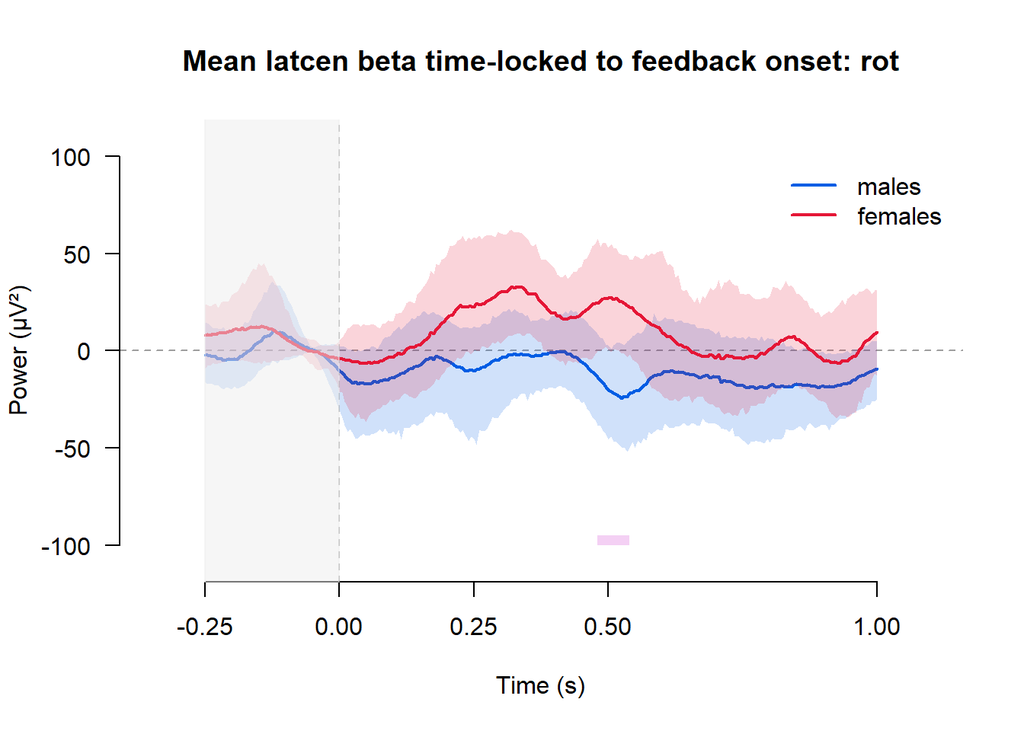

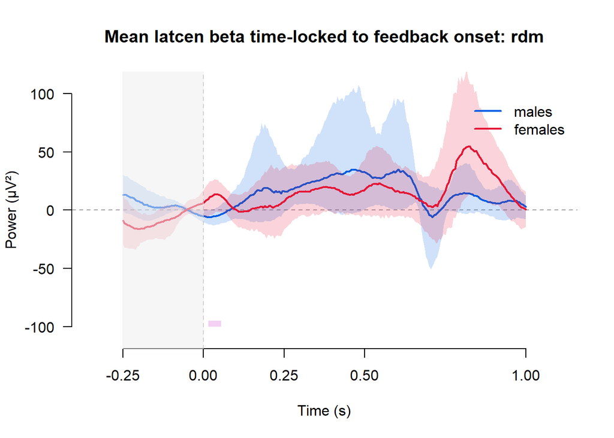

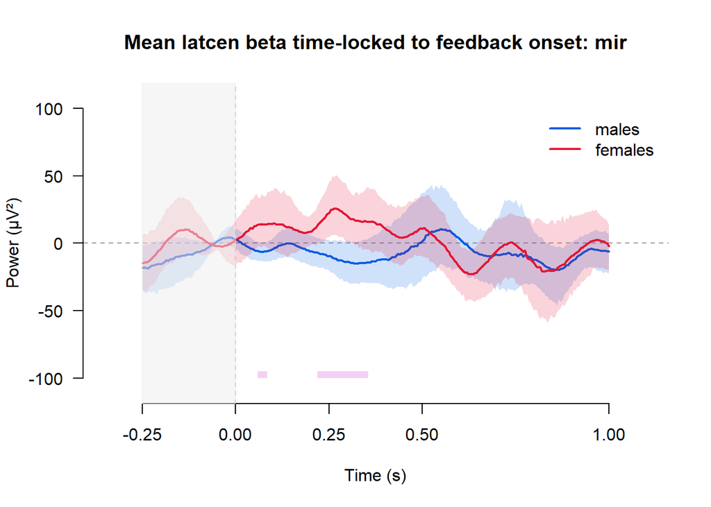

```r
plotSexPTypeTFRFRNPermTestSmallLargeDiffWaves(freqs = 'beta', roi = 'latcen')
```

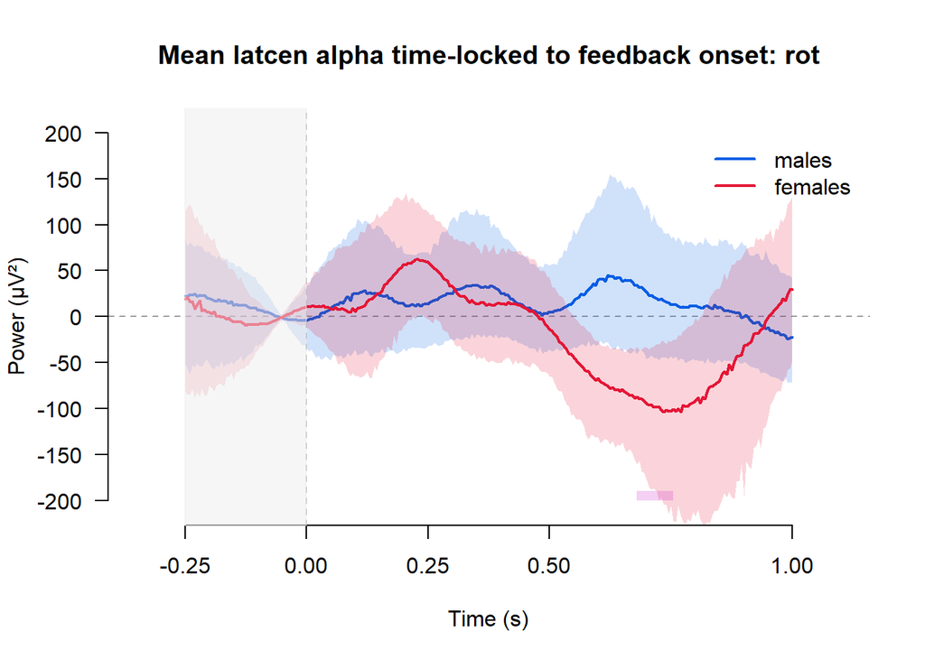

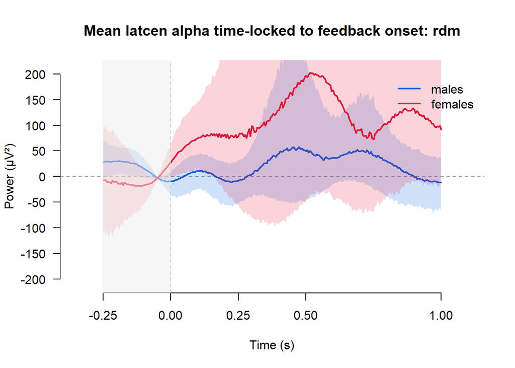

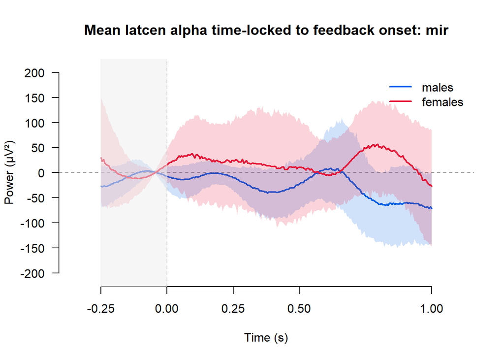

```r
plotSexPTypeTFRFRNPermTestSmallLargeDiffWaves(freqs = 'alpha', roi = 'latcen')
```